# Script for Figures from - (Mora Van Cauwelaert et al., 2022)

This script creates the different figures (except for Fig.1 (the model) and Fig.2-Spores against rainfall). **Part 1** shows the code for figure 3 and S1.3, **Part 2** for figures 4 (general MATI and time to MATI vs m), S1.6 (MATI vs ) and 5 (time series). **Part 3** Shows the code for figure 6.

Load Packages and colors

```r
mycols <- c("#021128","#1b4a64", "#3585a0", "#759580", "#c78f34", "#fd9706","#fdb81c","#fbdb30")
mycols3a <-c("#021128", "#fd9706", "#3585a0")
mycols3b <-c("#1b4a64", "#fdb81c", "#759580")
library(ggplot2)
library(patchwork)
library(tidyverse)
```

# Part 1 (Figures 3 and S1.3 One plant-level simulation)

## 1.1. Fig 3.AB

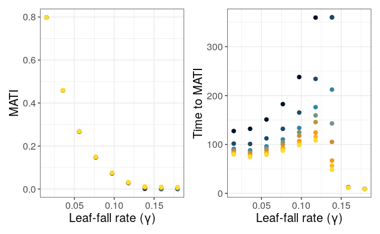

```r
setwd("~/Desktop/archivosTrabajandose_aborrar/articulo1_codigoFiguras/FiguresCodes/")

#we set the equilibrium point
datosFig_local<- read.csv("dataIndividualPlant.csv")
datosFig_local$Ieq <- datosFig_local$Imax1-datosFig_local$Imax1.Ieq

#quitar los ultmos valores
datosFig_local <-  datosFig_local[datosFig_local$g!= 0.2,]
datosFig_local$I0 <- datosFig_local$I0*100


#todo esto ya no va  estar
#cortar la simulacion a 300 (osea todos los valores mayores a 300, asumimo que fueron 300..) VERIF
#datosFig_local$tiempoImax1[datosFig_local$tiempoImax1 >300] <- 300


Fig3A <- datosFig_local  %>%
  filter(!(I0==2.3)) %>%
  filter(!(I0==6.7)) %>%
  ggplot(aes(g, Imax1))+  #change to Imax.Ieq for supp figure S1.2
  theme_bw()+
  geom_point(aes(color=as.factor(I0)), size=2) +  #corregir esto
  scale_color_manual(values= mycols)+
  theme(text = element_text(size=15))+
  theme(legend.position = "none")+
  labs(color= "Initial proportion of infected leaves", x= "Leaf-fall rate (\u03B3)", y= "MATI")

Fig3B <- datosFig_local  %>%
  filter(!(I0==2.3)) %>%
  filter(!(I0==6.7)) %>%
  ggplot(aes(g, tiempoImax1))+
  theme_bw()+
  theme(text = element_text(size=15))+
  theme(legend.position = "none")+
  geom_point(aes(color=as.factor(I0)), size=2) +  #corregir esto
  scale_color_manual(values= mycols)+
  labs(color= "Initial % of infected leaves", x= "Leaf-fall rate (\u03B3)", y= "Time to MATI")


Fig3AB <- Fig3A+Fig3B

Fig3AB
```

```r
#ggsave("fig1ParteAB_3.png", height = 4, width = 10)
```

## 1.2. Fig 3.CD

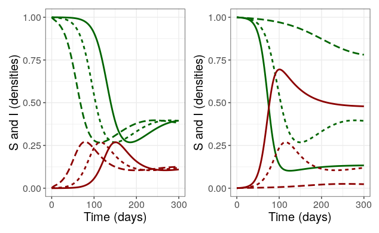

```r
d_ex_plant<- read.csv("examplesDataIndividualPlant.csv")

Nth.delete<-function(dataframe, n)dataframe[-(seq(n,to=nrow(dataframe),by=n)),] #funcion bajada para borrar lineas
d_ex_plant<- Nth.delete(d_ex_plant, 2)
d_ex_plant<- Nth.delete(d_ex_plant, 2)

library(dplyr)

#primerFiltro
parEj1<- filter(d_ex_plant, g == 0.056)
parEj2<- filter(d_ex_plant, I0== 0.01)

parEj1 <- parEj1 %>%
  filter(X.1<30001)
parEj2 <- parEj2 %>%
  filter(X.1<30001)


Fig3C <- ggplot(parEj1)+
  geom_line(aes(x=X.1*0.01, y=S, linetype=as.factor(I0)), color="darkgreen", size=1) +
  geom_line(aes(x=X.1*0.01, y=I, linetype=as.factor(I0)), color="darkred", size=1)+
  theme_bw()+
  theme(text = element_text(size=15))+
  theme(legend.position = "none")+
  labs(linetype= "I0", x= "Time (days)", y= "S and I (densities)")


Fig3D <- ggplot(parEj2)+
  geom_line(aes(x=X.1*0.01, y=S, linetype=as.factor(g)), color="darkgreen", size=1) +
  geom_line(aes(x=X.1*0.01, y=I, linetype=as.factor(g)), color="darkred", size=1)+
  theme_bw()+
  theme(text = element_text(size=15))+
  theme(legend.position = "none")+
  labs(linetype= "\u03B3", x= "Time (days)", y= "S and I (densities)")


  Fig3CD <- Fig3C+Fig3D
  #save figure
Fig3CD
```

# Part 2 (figures 4 (general MATI and time to MATI vs m), S1.6 (MATI vs ) and 5 (time series))

## 2. 1. Load the data frame and modify it only to plot the required values

```r
datosFig_Espacio <- read.csv("dataGeneralAverages.csv")

#add an ID per simulations  (990 IDs)
datosFig_Espacio$ID <- rep(1:990, each= 602)  # 602 is the number of steps per simulations after the filter
###transform steps to days
datosFig_Espacio$X <- datosFig_Espacio$X*0.01

#remove the middle value of Iini and filter the low value of g
datosFig_Espacio <- datosFig_Espacio %>%
  filter(!(Iini==0.010)) %>%
  filter(g == 0.015)
#%>%
 # filter(g== 0.056)
```

## 2.2. Database modifications for figures 4 and 5

```r
#obtain the  maximum values of each serie, according to the ID
datosMax<- datosFig_Espacio %>% group_by(g,m, Iini, sim, patron, Dc, ID) %>%
  summarise_all(max)

#subselct in the general data frame rows that contain these maximum values. This procedure works since the values have mutiple decimals, and we don't have to simulations with the exact same value

dgInf <- datosFig_Espacio[datosFig_Espacio$I_prom %in% datosMax$I_prom, ]
dgInf<- dgInf %>% select(!c(S_prom,S_sd,X_prom,X_sd, I_sd))

#we merge the simulatons per planting pattern to summarise the random simulations and have an average and a standard deviation, only for that planting pattern
dgInf_ave <- dgInf  %>% group_by(g,m, Iini, patron) %>%
  summarise(meanDc= mean(Dc), sdDc= sd(Dc), meanImax=mean(I_prom), sdImax= sd(I_prom),meanTime=mean(X), sdTime= sd(X), ID=mean(ID) )
```

## 2.3. Procedure to define the time lag and the growth per se from each averaged run.

We estimate the day when the slope was higher than 0.001, this is, an increase of 0.1% of infection per day

```r
#We estimate the slope for each run
y2 <- datosFig_Espacio$I_prom[2:length(datosFig_Espacio$I_prom)]
y1 <- datosFig_Espacio$I_prom[1:length(datosFig_Espacio$I_prom)-1]

change <- y2-y1
change <- append(change, 0, 0)
datosFig_Espacio$slope <- change/0.5 # 0.5 is the time step between each point

#we now remove the values of the slopes for the first value or each simulation (since it does not make sense)
datosFig_Espacio$slope[datosFig_Espacio$X == 0.49] <- 0

#We group by Id and filter the first value where the slope is higher than 0.001

datosSLOPE <- datosFig_Espacio %>%
  group_by(ID) %>%
  filter(slope>0.001) %>%
  filter(row_number()==1)

#we average in order to have the mean values for the random pattern

datosSLOPE_ave <- datosSLOPE   %>% group_by(g,m, Iini, patron) %>%
  summarise(meanTimelag= mean(X), sdTimelag= sd(X), ID=mean(ID))
#we merge the new values to the previous data frame, by ID.

dgInf_ave <- merge(dgInf_ave, datosSLOPE_ave[c(5,6,7)], by= "ID")
dgInf_ave$meanGrow <- dgInf_ave$meanTime-dgInf_ave$meanTimelag


# this code generates the necessary csv for table S3.
#write.csv(dgInf_ave, "~/Desktop/archivosTrabajandose_aborrar/articulo1_codigoFiguras/FiguraParcela/datosTimeLag.csv")
```

## 2.4. Figure 4 (MATI and time to MATI vs m)

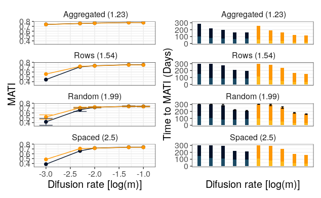

```r
Fig4_A<- dgInf_ave %>%
 ggplot(aes(x=log10(m)))+
  geom_line(aes(y = meanImax, col=as.character(Iini)), size=0.5) +
  geom_point(aes(y = meanImax, col=as.character(Iini)), size= 2) +
  geom_errorbar(aes(ymin = meanImax - sdImax, ymax = meanImax + sdImax, col=as.character(Iini)),alpha=0.75) +
  facet_wrap(~ patron, ncol = 1) +
  scale_color_manual(values= mycols3a)+
  theme_bw()+
  theme(strip.background = element_rect(color="white", fill="white", size=1.5))+
  theme(text = element_text(size=15))+
  theme(legend.position = "none")+
  labs(x= "Difusion rate [log(m)]", y= "MATI", col= "Initial proportion of infected trees")

#Save the figure

#gather for ggplot viusalization
dgInf_bars <- gather(dgInf_ave, "classTime", "value", c(12,14))
dgInf_bars$Iini_classTime <- paste(dgInf_bars$Iini, dgInf_bars$classTime)

#this figure is not the final fig 4 figure (we editted with inkscape using this figure)
Fig4_B<- dgInf_bars  %>%
  ggplot(aes(x = as.numeric(interaction(log10(m),Iini)), y= value, group=Iini_classTime, fill= Iini_classTime))+
  geom_bar(stat= "identity", width = 0.3)+
  geom_errorbar(aes(ymin = meanTime - sdTime, ymax = meanTime + sdTime),col="black",alpha=0.75, width = 0.2) +
  facet_wrap(~ patron, ncol = 1) +
  scale_fill_manual(values= mycols[c(1,2,6, 7)])+
  theme_bw()+
  theme(strip.background = element_rect(color="white", fill="white", size=1.5))+
  theme(text = element_text(size=15))+
  theme(legend.position = "none")+
  scale_x_continuous(breaks=c(-3,-2.5,-2, -1.5, -1), labels =c("-3","-2.5","-2", "-1.5", "-1"))+ ##VER
  labs(x= "Difusion rate [log(m)]", y= "Time to MATI (Days)", col= "Initial infected trees (%)")

#save the figure
Fig4_A + Fig4_B
```

## 2.5. Figure S1. 6 (MATI and time to MATI vs )

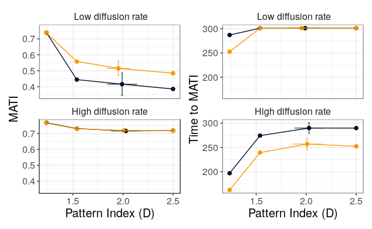

```r
dgInf_ave$m[dgInf_ave$m == "0.001"] <- " Low diffusion rate" # le pongo un espacio de más para el orden final de la figura
dgInf_ave$m[dgInf_ave$m == "0.01"] <- "High diffusion rate"


FigS1_6_MATIvsD<- dgInf_ave%>%
  filter(!(m==0.1)) %>%
  filter(!(m==0.005)) %>%
  filter(!(m==0.05)) %>%
  #g == 0.056
  #  filter(!(IresPro==5)) %>%
  #filter(!(meanTime>399))%>%  #esnayo
  ggplot(aes(x=meanDc, y= meanImax))+
  geom_point(aes(y = meanImax, col= as.factor(Iini)), size=2) +
  geom_errorbar(aes(ymin = meanImax - sdImax, ymax = meanImax + sdImax, col= as.factor(Iini)),alpha=0.75) +
  geom_errorbarh(aes(xmin = meanDc - sdDc, xmax = meanDc + sdDc, col=as.factor(Iini)),alpha=0.75)+
  geom_line(aes(y = meanImax, col=as.character(Iini)), size=0.5) +
  facet_wrap(~ m, ncol = 1) +
  scale_color_manual(values= mycols[c(1,6,2,7)])+
  theme_bw()+
  theme(strip.background = element_rect(color="white", fill="white", size=1.5))+
  theme(text = element_text(size=15))+
  theme(legend.position = "none")+
  labs(x= "Pattern Index (D)", y= "MATI", col= "Initial proportion of infected trees")


#save figure

FigS1_6_timeMATIvsD<- dgInf_ave%>%
  filter(!(m==0.1)) %>%
  filter(!(m==0.005)) %>%
  filter(!(m==0.05)) %>%
  ggplot(aes(x=meanDc, y= meanTime))+
  geom_point(aes(y = meanTime, col= as.factor(Iini)), size=2) +
  geom_errorbar(aes(ymin = meanTime - sdTime, ymax = meanTime + sdTime, col= as.factor(Iini)),alpha=0.75) +
  geom_errorbarh(aes(xmin = meanDc - sdDc, xmax = meanDc + sdDc, col=as.factor(Iini)),alpha=0.75)+
  geom_line(aes(y = meanTime, col=as.character(Iini)), size=0.5) +
  facet_wrap(~ m, ncol = 1) +
  scale_color_manual(values= mycols[c(1,6,2,7)])+
  theme_bw()+
  theme(strip.background = element_rect(color="white", fill="white", size=1.5))+
  theme(text = element_text(size=15))+
  theme(legend.position = "none")+
  labs(x= "Pattern Index (D)", y= "Time to MATI", col= "Initial proportion of infected trees")

#save figure
FigS1_6_MATIvsD + FigS1_6_timeMATIvsD
```

## 2.6. Time series of figure 5.

We know subselect from the general dataframe of averages, some specific values of m, to plot the time series in figure 5.

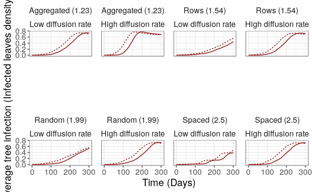

```r
datosFig_Espacio$m[datosFig_Espacio$m == "0.001"] <- " Low diffusion rate" # le pongo un espacio de más para el orden final de la figura
datosFig_Espacio$m[datosFig_Espacio$m == "0.01"] <- "High diffusion rate"


Fig5_timeSeries <- datosFig_Espacio %>%
  filter(!(m==0.1)) %>%
  filter(!(m==0.005)) %>%
  filter(!(m==0.05)) %>%
  filter(sim ==1 | sim==2) %>% # we take each simulation and 1 simulation for the random
  ggplot(aes(x=X))+
  geom_line(aes(y=I_prom, linetype=as.factor(Iini)), color="darkred")+
  facet_wrap(~patron*m, ncol = 4, labeller = label_wrap_gen(multi_line=TRUE)) +
  theme_bw()+
  theme(text = element_text(size=15))+
  theme(panel.spacing.y = unit(6, "lines"))+
  theme(panel.spacing.x = unit(1, "lines"))+
  theme(legend.position = "none")+
  theme(strip.background = element_rect(color="white", fill="white", size=1.5))+
  scale_fill_manual(values= mycols3a)+
  labs(linetype= "I0", x= "Time (Days)", y= "Average tree infection (Infected leaves density)")

#save figure
Fig5_timeSeries
```

# Part 3. Figure 6 (histograms)

## 3.1 Load and modify data base

```r
setwd("~/Desktop/archivosTrabajandose_aborrar/articulo1_codigoFiguras/FiguresCodes/")

datosPicosPlanta <-read.csv("dataPeaks.csv", header = TRUE)

#https://www.r-bloggers.com/2013/08/date-formats-in-r/

datosPicosPlanta$Patron<- as.character(datosPicosPlanta$Patron)
datosPicosPlanta$contador <- 1
datosPicosPlanta$ID <- rep(1:(dim(datosPicosPlanta)[1]/50), each= 50)
datosPicosPlanta$TiempoImax <- round(datosPicosPlanta$TiempoImax)

#esto marca los valores de D. Es importante el random es el promedio de esta simulacion
datosPicosPlanta[datosPicosPlanta=="random"] <- "Random (1.99)"
datosPicosPlanta[datosPicosPlanta=="spaced"] <- "Spaced (2.5)"
datosPicosPlanta[datosPicosPlanta=="aggregated"] <- " Aggregated (1.23)"
datosPicosPlanta[datosPicosPlanta=="rows"] <- " Rows (1.54)"
```

```r
datosHisto <- datosPicosPlanta %>%
   filter(TiempoImax<300) %>%
  filter(g==0.015) %>%
  #filter(g==0.056) %>%  ##use only for SUPP

   filter(!(tasaMig==0.005)) %>%
   filter(!(tasaMig==0.05)) %>%
   filter(!(tasaMig==0.1)) %>%
   filter(!(Ini ==0.01))%>%
  filter(Sim ==1 | Sim==2)
```

```r
datosHisto$numCat <- as.integer(datosHisto$TiempoImax/14)
datosHisto<- datosHisto %>%  unite("mig_Ini", tasaMig, Ini, remove = FALSE)

datosHisto$tasaMig <- as.character(datosHisto$tasaMig)
datosHisto$tasaMig[datosHisto$tasaMig == "0.001"] <- " Low diffusion rate"
datosHisto$tasaMig[datosHisto$tasaMig == "0.01"] <- "High diffusion rate"

# grooup by pattern to count the number of trees that reach the max in the same cat
datosTotal <- datosHisto %>% group_by(Sim, Patron, tasaMig, g, Dc, Ini, ID, numCat) %>%   #aqui quite el tiempoImax
  summarise(contadorAgg = sum(contador))
# for each ID, make the cumulative sum
datosTotal <- datosTotal %>%
  group_by(ID) %>%
  mutate(csum = cumsum(contadorAgg)/50)  # el

#visualisation
datosTotal$Ini <- as.character(datosTotal$Ini)
datosTotal$Ini[datosTotal$Ini== "0.001"] <- " Low initial infection (I0)" # le pongo un espacio de más para el orden final de la figura
datosTotal$Ini[datosTotal$Ini == "0.1"] <- "High initial infection (I0)"
datosTotal<- datosTotal %>%  unite("mig_Ini", tasaMig, Ini, remove = FALSE)
```

## 3.2 Fig 6- Histogram

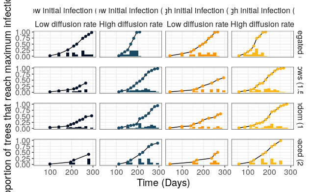

```r
Fig6_histoAcc <-   datosTotal%>%
  ggplot(aes(x= numCat*14))+
#  geom_point(aes(color = mig_Ini), size = 2)+
  geom_col(width=14, aes(y= contadorAgg/50, fill = mig_Ini)) +#geom_errorbar(aes(ymin=avTrees-sdTrees, ymax=avTrees+sdTrees, color=mig_Ini), size=1)+
  geom_line(aes(y= csum, group= mig_Ini), size = 0.5, color = "black")+
  geom_point(aes(y = csum, color = mig_Ini), size =1.5)+
  theme_bw()+
  theme(text = element_text(size=15))+
  theme(panel.spacing.y = unit(1, "lines"))+
  theme(legend.position = "none")+
  theme(strip.background = element_rect(color="white", fill="white", size=1.5))+
  scale_color_manual(values= mycols[c(1,6,2,7)])+
  scale_fill_manual(values= mycols[c(1,6,2,7)])+
  facet_grid(Patron~Ini*tasaMig)+
  labs(linetype= "I0", x= "Time (Days)", y= "Proportion of trees that reach maximum infection")



Fig6_histoAcc
```